# Prediction Modeling

Penny Robinson

2023-02-16

Overview: This study will attempt to predict the manner in which dumbbell exercises were conducted based on the case study - “Qualitative Activity Recognition of Weight Lifting Exercises”, authored by E. Velloso, A. Bulling, H. Gellersen, Q. Ugulino, and H. Fuks. The study can be found here: (http://groupware.les.inf.puc-rio.br/har). The case study focused on participants performing dumbbell bicep curls in five different manners: correctly and four other ways. Measurements were collected via wearable devices and sensors on the belt (worn across the back), glove, arm band, and dumbbell. Roll, pitch, and yaw angles were collected along with the following features for each: mean, variance, standard deviation, maximum, minimum, amplitude, kurtosis, and skewness.

The following packages were installed and used in support of the analysi: dplyr, ggplot2, randomForest, and caret

Data:

Training and test data were downloaded from the below:

Training – https://d396qusza40orc.cloudfront.net/predmachlearn/pml-training.csv

Test - https://d396qusza40orc.cloudfront.net/predmachlearn/pml-testing.csv

The datasets were loaded as follows:

```r
untidy_train<-read.csv("pml-training.csv",header=TRUE)
untidy_test<-read.csv("pml-testing.csv", header=TRUE)
```

```r
tidy_train<-select(untidy_train, c(2,3,4,8,9,10,11, 46,47,48,49,84,85,86,102,122, 123, 124, 140, 160))
tidy_train<-tidy_train %>% mutate_if (is.numeric, as.numeric)
tidy_train<-tidy_train %>% mutate_if(is.character, as.factor)
```

Next, a portion of the training set was reserved for validation in order to test the model before using it on the true test data.

```r
split_tidy_train<-createDataPartition(tidy_train$classe, p=.8, list=FALSE)
#selecting 20% of data for validation
valset<-tidy_train[-split_tidy_train,]
trainset<-tidy_train[split_tidy_train,]
```

The test data was cleaned similarly to the training data in order to run the prediction model later.

```r
tidy_test<-select(untidy_test, c(2,3,4,8,9,10,11, 46,47,48,49,84,85,86,102,122, 123, 124, 140))
tidy_test<-tidy_test %>% mutate_if (is.numeric, as.numeric)
tidy_test<-tidy_test %>% mutate_if(is.character, as.factor)
```

Below is a quick look at the now tidy training set - named trainset.

```r
str(trainset)
```

```
## 'data.frame':    15699 obs. of  20 variables:
##  $ user_name           : Factor w/ 6 levels "adelmo","carlitos",..: 2 2 2 2 2 2 2 2 2 2 ...
##  $ raw_timestamp_part_1: num  1.32e+09 1.32e+09 1.32e+09 1.32e+09 1.32e+09 ...
##  $ raw_timestamp_part_2: num  788290 808298 120339 196328 304277 ...
##  $ roll_belt           : num  1.41 1.41 1.48 1.48 1.45 1.42 1.42 1.43 1.45 1.45 ...
##  $ pitch_belt          : num  8.07 8.07 8.05 8.07 8.06 8.09 8.13 8.16 8.17 8.18 ...
##  $ yaw_belt            : num  -94.4 -94.4 -94.4 -94.4 -94.4 -94.4 -94.4 -94.4 -94.4 -94.4 ...
##  $ total_accel_belt    : num  3 3 3 3 3 3 3 3 3 3 ...
##  $ roll_arm            : num  -128 -128 -128 -128 -128 -128 -128 -128 -128 -128 ...
##  $ pitch_arm           : num  22.5 22.5 22.1 22.1 22 21.9 21.8 21.7 21.6 21.5 ...
##  $ yaw_arm             : num  -161 -161 -161 -161 -161 -161 -161 -161 -161 -161 ...
##  $ total_accel_arm     : num  34 34 34 34 34 34 34 34 34 34 ...
##  $ roll_dumbbell       : num  13.1 13.1 13.4 13.4 13.4 ...
##  $ pitch_dumbbell      : num  -70.5 -70.6 -70.4 -70.4 -70.8 ...
##  $ yaw_dumbbell        : num  -84.9 -84.7 -84.9 -84.9 -84.5 ...
##  $ total_accel_dumbbell: num  37 37 37 37 37 37 37 37 37 37 ...
##  $ roll_forearm        : num  28.4 28.3 28.1 28 27.9 27.9 27.8 27.7 27.7 27.6 ...
##  $ pitch_forearm       : num  -63.9 -63.9 -63.9 -63.9 -63.9 -63.9 -63.8 -63.8 -63.8 -63.8 ...
##  $ yaw_forearm         : num  -153 -153 -152 -152 -152 -152 -152 -152 -152 -152 ...
##  $ total_accel_forearm : num  36 36 36 36 36 36 36 36 36 36 ...
##  $ classe              : Factor w/ 5 levels "A","B","C","D",..: 1 1 1 1 1 1 1 1 1 1 ...
```

With the dataset cleaned, the variables are viewed to find any relationships or correlations in the data.

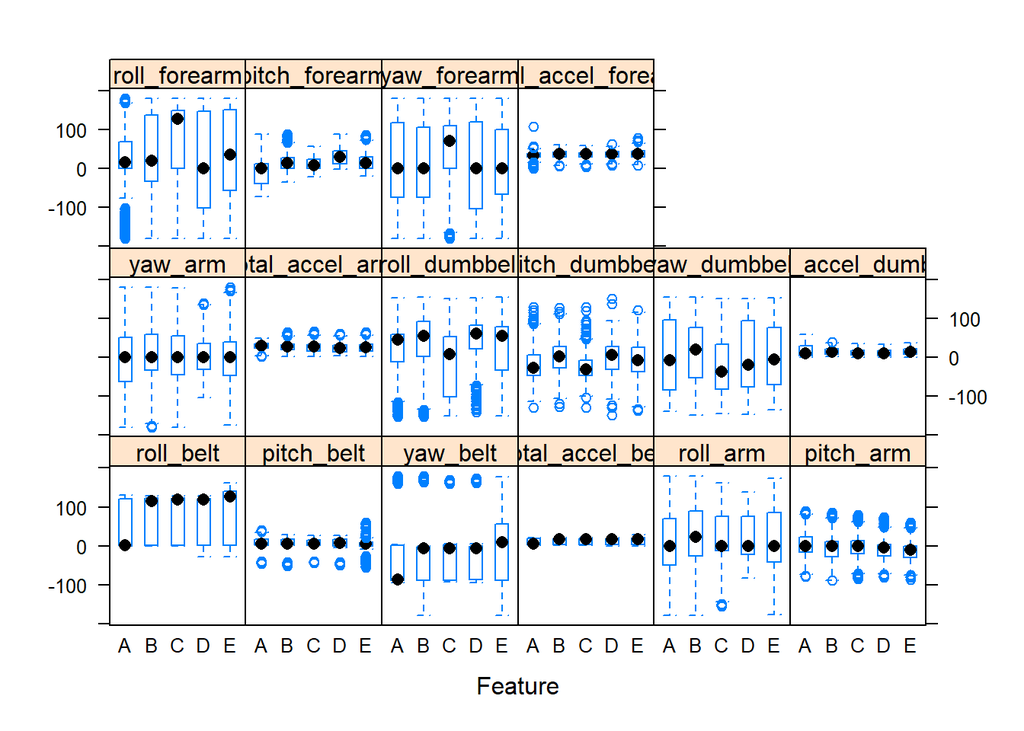

```r
xdata<-trainset[,4:19]
xtime<-trainset[,2:3]
ydata<-trainset[,20]
featurePlot(x=xdata, y=ydata, plot="box")
```

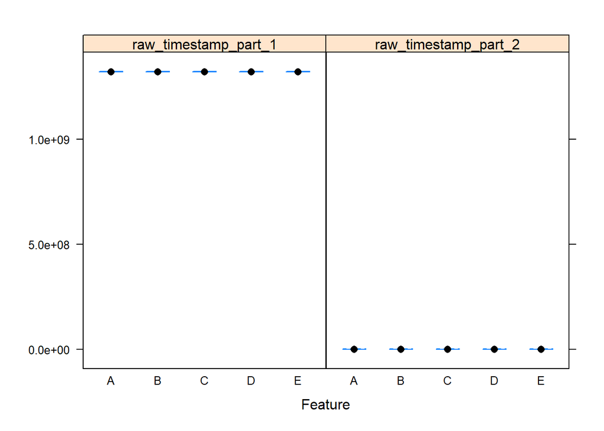

```r
featurePlot(x=xtime, y=ydata, plot="box")
```

The classification (class levels) and corresponding percentage of the training set shown below correspond to A: exactly according to the specification, B: throwing the elbows, C: lifting the dumbbell only halfway, D: lowering the dumbbell only halfway, and E: throwing the hips to the front.

```r
levels(trainset$classe)
```

```
## [1] "A" "B" "C" "D" "E"
```

```r
percentage<-prop.table(table(trainset$classe))*100
cbind(freq=table(trainset$classe),percentage=percentage)
```

```
##   freq percentage
## A 4464   28.43493
## B 3038   19.35155
## C 2738   17.44060
## D 2573   16.38958
## E 2886   18.38334
```

```r
corrMatrix<-cor(trainset[,2:19])
diag(corrMatrix)=0
corrMatrix
```

```
##                      raw_timestamp_part_1 raw_timestamp_part_2   roll_belt
## raw_timestamp_part_1          0.000000000          0.001034205  0.37982841
## raw_timestamp_part_2          0.001034205          0.000000000  0.01080579
## roll_belt                     0.379828411          0.010805788  0.00000000
## pitch_belt                    0.189004542         -0.007895544 -0.21949881
## yaw_belt                      0.171846935          0.011956380  0.81568667
## total_accel_belt              0.379403201          0.009339949  0.98083299
## roll_arm                     -0.063521518         -0.011056263 -0.37345797
## pitch_arm                    -0.045232519          0.007518641  0.05996586
## yaw_arm                      -0.120008447         -0.009806532 -0.22431382
## total_accel_arm              -0.140761953          0.021611174 -0.27679782
## roll_dumbbell                -0.126943346         -0.003046751 -0.12639142
## pitch_dumbbell                0.198730503         -0.001497477  0.06515645
## yaw_dumbbell                  0.333339812         -0.004783776  0.02147727
## total_accel_dumbbell         -0.295187574          0.014539022 -0.19045501
## roll_forearm                  0.081730318          0.013856501 -0.14849210
## pitch_forearm                 0.232682455          0.004725834  0.17733389
## yaw_forearm                  -0.091587638         -0.007633720 -0.26315329
## total_accel_forearm           0.017975466          0.012149737  0.06645072
##                        pitch_belt    yaw_belt total_accel_belt    roll_arm
## raw_timestamp_part_1  0.189004542  0.17184693      0.379403201 -0.06352152
## raw_timestamp_part_2 -0.007895544  0.01195638      0.009339949 -0.01105626
## roll_belt            -0.219498814  0.81568667      0.980832992 -0.37345797
## pitch_belt            0.000000000 -0.69973086     -0.143077502  0.17207911
## yaw_belt             -0.699730865  0.00000000      0.762849672 -0.33858929
## total_accel_belt     -0.143077502  0.76284967      0.000000000 -0.36302223
## roll_arm              0.172079106 -0.33858929     -0.363022226  0.00000000
## pitch_arm            -0.160062328  0.13411164      0.053316246 -0.04070704
## yaw_arm               0.141133907 -0.22530602     -0.209450621  0.40037571
## total_accel_arm       0.085918860 -0.23521507     -0.265929416  0.05928653
## roll_dumbbell        -0.347988984  0.09503482     -0.131372162 -0.15145705
## pitch_dumbbell        0.234227784 -0.09371175      0.060818859  0.22742112
## yaw_dumbbell          0.660506411 -0.34987216      0.056223440  0.27975139
## total_accel_dumbbell -0.317281114  0.04582981     -0.169771933 -0.15471331
## roll_forearm          0.144069152 -0.17810573     -0.110466170  0.07505615
## pitch_forearm         0.255294543 -0.02898048      0.187138845  0.16601019
## yaw_forearm           0.049504556 -0.19341271     -0.235631927  0.23708835
## total_accel_forearm  -0.327675582  0.22593926      0.032785302 -0.01634790
##                         pitch_arm      yaw_arm total_accel_arm roll_dumbbell
## raw_timestamp_part_1 -0.045232519 -0.120008447    -0.140761953 -0.1269433459
```

[output cut: 59 more lines]

```
## pitch_belt                  -0.327675582
## yaw_belt                     0.225939257
## total_accel_belt             0.032785302
## roll_arm                    -0.016347904
## pitch_arm                    0.107586382
## yaw_arm                     -0.121392307
## total_accel_arm             -0.068256192
## roll_dumbbell                0.181965375
## pitch_dumbbell               0.006978514
## yaw_dumbbell                -0.186233460
## total_accel_dumbbell         0.124564352
## roll_forearm                -0.081232790
## pitch_forearm               -0.177128809
## yaw_forearm                  0.194402561
## total_accel_forearm          0.000000000
```

Several models were used to as a way to evaluate the algorithms to see which model would be best for predicting the classification of how dumbbell exercise was conducted based on the different roll, pitch, yaw, and acceleration features from the 4 different sensors.

Ten fold cross validation was run with the linear discriminant analysis, classification and regression trees, K nearest neighbors, and random forest models.

A summary of all the models are shown below.

```r
allfits<-resamples(list(lda=fit.lda, cart=fit.cart, knn=fit.knn, rf=fit.rf))
summary(allfits)
```

```
##
## Call:
## summary.resamples(object = allfits)
##
## Models: lda, cart, knn, rf
## Number of resamples: 10
##
## Accuracy
##           Min.   1st Qu.    Median      Mean   3rd Qu.      Max. NA's
## lda  0.5496183 0.5542486 0.5659212 0.5647515 0.5735903 0.5815287    0
## cart 0.4576703 0.5615792 0.5826139 0.5670593 0.6018804 0.6386233    0
## knn  0.2976418 0.3071533 0.3135974 0.3140941 0.3212345 0.3316359    0
## rf   0.9955386 0.9969730 0.9980910 0.9978343 0.9987261 0.9993631    0
##
## Kappa
##           Min.   1st Qu.    Median      Mean   3rd Qu.      Max. NA's
## lda  0.4279007 0.4329355 0.4476846 0.4463082 0.4578988 0.4667445    0
## cart 0.3003467 0.4358571 0.4655982 0.4466674 0.4933936 0.5446347    0
## knn  0.1144088 0.1221456 0.1321768 0.1322468 0.1400372 0.1537766    0
## rf   0.9943561 0.9961714 0.9975854 0.9972607 0.9983887 0.9991944    0
```

The random forest model was the best model with a .99 accuracy and will be used for prediction.

```r
print(fit.rf)
```

```
## Random Forest
##
## 15699 samples
##    19 predictor
##     5 classes: 'A', 'B', 'C', 'D', 'E'
##
## No pre-processing
## Resampling: Cross-Validated (10 fold)
## Summary of sample sizes: 14128, 14130, 14127, 14129, 14130, 14128, ...
## Resampling results across tuning parameters:
##
##   mtry  Accuracy   Kappa
##    2    0.9943311  0.9928291
##   12    0.9978343  0.9972607
##   23    0.9971970  0.9964548
##
## Accuracy was used to select the optimal model using the largest value.
## The final value used for the model was mtry = 12.
```

A confusion matrix showing the predicted values from the random forest model versus the actual values will be generated with the training dataset.

```r
confusionMatrix(trainset$classe, predict(fit.rf, trainset))
```

```
## Confusion Matrix and Statistics
##
##           Reference
## Prediction    A    B    C    D    E
##          A 4464    0    0    0    0
##          B    0 3038    0    0    0
##          C    0    0 2738    0    0
##          D    0    0    0 2573    0
##          E    0    0    0    0 2886
##
## Overall Statistics
##
##                Accuracy : 1
##                  95% CI : (0.9998, 1)
##     No Information Rate : 0.2843
##     P-Value [Acc > NIR] : < 2.2e-16
##
##                   Kappa : 1
##
##  Mcnemar's Test P-Value : NA
##
## Statistics by Class:
##
##                      Class: A Class: B Class: C Class: D Class: E
## Sensitivity            1.0000   1.0000   1.0000   1.0000   1.0000
## Specificity            1.0000   1.0000   1.0000   1.0000   1.0000
## Pos Pred Value         1.0000   1.0000   1.0000   1.0000   1.0000
## Neg Pred Value         1.0000   1.0000   1.0000   1.0000   1.0000
## Prevalence             0.2843   0.1935   0.1744   0.1639   0.1838
## Detection Rate         0.2843   0.1935   0.1744   0.1639   0.1838
## Detection Prevalence   0.2843   0.1935   0.1744   0.1639   0.1838
## Balanced Accuracy      1.0000   1.0000   1.0000   1.0000   1.0000
```

The accuracy is good. Again we check the model by running a confusion matrix with the validation data.

```r
confusionMatrix(valset$classe, predict(fit.rf, valset))
```

```
## Confusion Matrix and Statistics
##
##           Reference
## Prediction    A    B    C    D    E
##          A 1116    0    0    0    0
##          B    2  757    0    0    0
##          C    0    2  682    0    0
##          D    0    0    1  641    1
##          E    0    0    0    0  721
##
## Overall Statistics
##
##                Accuracy : 0.9985
##                  95% CI : (0.9967, 0.9994)
##     No Information Rate : 0.285
##     P-Value [Acc > NIR] : < 2.2e-16
##
##                   Kappa : 0.9981
##
##  Mcnemar's Test P-Value : NA
##
## Statistics by Class:
##
##                      Class: A Class: B Class: C Class: D Class: E
## Sensitivity            0.9982   0.9974   0.9985   1.0000   0.9986
## Specificity            1.0000   0.9994   0.9994   0.9994   1.0000
## Pos Pred Value         1.0000   0.9974   0.9971   0.9969   1.0000
## Neg Pred Value         0.9993   0.9994   0.9997   1.0000   0.9997
## Prevalence             0.2850   0.1935   0.1741   0.1634   0.1840
## Detection Rate         0.2845   0.1930   0.1738   0.1634   0.1838
## Detection Prevalence   0.2845   0.1935   0.1744   0.1639   0.1838
## Balanced Accuracy      0.9991   0.9984   0.9990   0.9997   0.9993
```

Since the accuracy again is good, the prediction can be run on the test data with confidence. The test data set was previously cleaned using same process as with training data.

```r
predictionTest<-predict(fit.rf, tidy_test)
predictionTest
```

```
##  [1] B A B A A E D B A A B C B A E E A B B B
## Levels: A B C D E
```

The classification of how the dumbbell exercises were conducted was predicted for twenty cases in the test set data (shown above).

Summary. The data set contained a lot of information gathered from the sensors. Once that data was reduced and cleaned to focus on the most relevant variables, a random forest model was fitted to data and then a prediction was conducted on the test data. The results showed that the model was able to accurately predict how the dumbbell exercises were conducted on a separate data set.